# ABDA_Week1 Vedant Shah 987144

```r
library(tidyverse)
library(ggbeeswarm)
library(aida)

dolphin <- aida::aidata
```

### Exercise 2

1. Take the dolphin data set and store a reduced variant of it. The new data frame should contain only the columns `condition`, `group`, and `xpos_flips`, `correct`. And within the `correct` vector, we are only interested in the correct trials (= 1). Filter accordingly.

```r
dolphin_selected <- dolphin %>%
  dplyr::select(condition, group, xpos_flips, correct) %>% filter(correct == 1)
head(dolphin_selected)
```

```
## # A tibble: 6 x 4
##   condition group xpos_flips correct
##   <chr>     <chr>      <dbl>   <dbl>
## 1 Atypical  touch          3       1
## 2 Typical   touch          1       1
## 3 Atypical  touch          0       1
## 4 Typical   touch          2       1
## 5 Atypical  touch          2       1
## 6 Typical   touch          1       1
```

2. Create an aggregated data frame that contains the mean `xpos_flips` value and the standard deviation for `group` and `condition`.

```r
dolphin_aggregate <-
  dolphin_selected %>%
  group_by(condition, group) %>%
  summarise(mean_flips = mean(xpos_flips),
            sd_flips  = sd(xpos_flips))

dolphin_aggregate
```

```
## # A tibble: 4 x 4
## # Groups:   condition [2]
##   condition group mean_flips sd_flips
##   <chr>     <chr>      <dbl>    <dbl>
## 1 Atypical  click      1.33     1.23
## 2 Atypical  touch      0.797    1.10
## 3 Typical   click      0.956    1.05
## 4 Typical   touch      0.572    0.938
```

3. Rename the new vectors for the mean xflips and their sd to `xflips_mean` and `xflips_sd`

```r
dolphin_aggregate <- dolphin_aggregate %>% rename(xflips_mean = mean_flips, xflips_sd = sd_flips)
dolphin_aggregate
```

```
## # A tibble: 4 x 4
## # Groups:   condition [2]
##   condition group xflips_mean xflips_sd
##   <chr>     <chr>       <dbl>     <dbl>
## 1 Atypical  click       1.33      1.23
## 2 Atypical  touch       0.797     1.10
## 3 Typical   click       0.956     1.05
## 4 Typical   touch       0.572     0.938
```

4. Do all of the above (a-c) in one pipeline.

```r
dolphin_pipeline <- dolphin %>%
  dplyr::select(condition, group, xpos_flips, correct) %>% filter(correct == 1) %>%
group_by(condition, group) %>%
  summarise(mean_flips = mean(xpos_flips),
            sd_flips  = sd(xpos_flips)) %>% rename(xflips_mean = mean_flips, xflips_sd = sd_flips)

dolphin_pipeline
```

```
## # A tibble: 4 x 4
## # Groups:   condition [2]
##   condition group xflips_mean xflips_sd
##   <chr>     <chr>       <dbl>     <dbl>
## 1 Atypical  click       1.33      1.23
## 2 Atypical  touch       0.797     1.10
## 3 Typical   click       0.956     1.05
## 4 Typical   touch       0.572     0.938
```

## Exercise 2

1. Plot AUC values as a function of group in a density plot (`geom_density`).
2. Color code the curves (the border and the filling) as follows: “orange” for the click group and “black” for the touch group.
3. Make the density curves semi-transparent with the `alpha` argument
4. Add the aida_theme to the plot.
5. BONUS: Add the mean values for both groups into the density plot as a line.

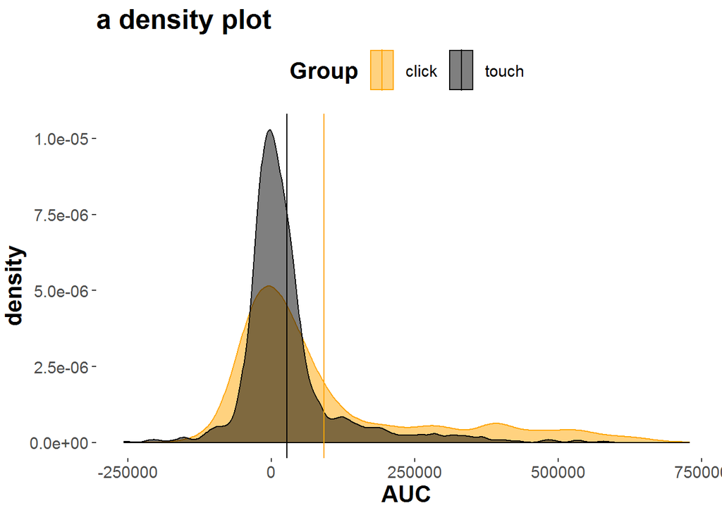

```r
mean <- dolphin %>% group_by(group) %>% summarise(mean = mean(AUC))

ggplot(dolphin, aes(x= AUC, fill = group, color = group)) +
  geom_density(alpha = 0.5) +
  ggtitle("a density plot") +
  scale_fill_manual(
                    guide = guide_legend("Group"),
                    values = c("orange", "black")) +
    scale_colour_manual(
                    guide = guide_legend("Group"),
                    values = c("orange", "black")) +
  geom_vline(data = mean, aes(xintercept = mean, color = group))+
  theme_aida()
```